# Quick R basic review

## Ch01：為何要學 R 語言？

## R 是專門為資料分析而設計的程式語言

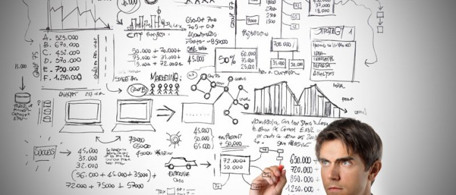

### R 可以執行大多數的統計計算、機器學習、資料採礦方法

取自 http://goo.gl/CkXlvY

## 免費、開源、豐沛的社群資源

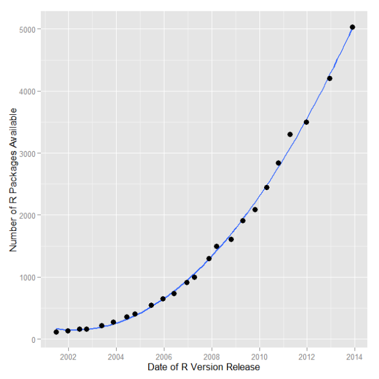

### 很容易擴充和客製化

取自 http://goo.gl/AwfHLx

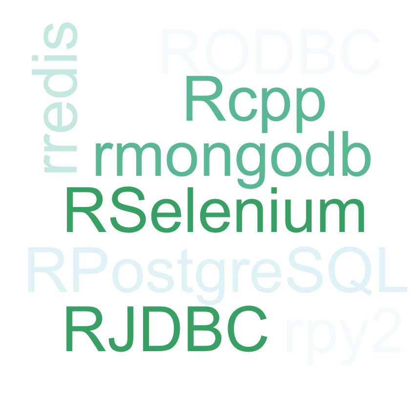

### 很容易和其他工具做整合

取自 http://goo.gl/jvNnG3

## R 可以輸出高品質的視覺化

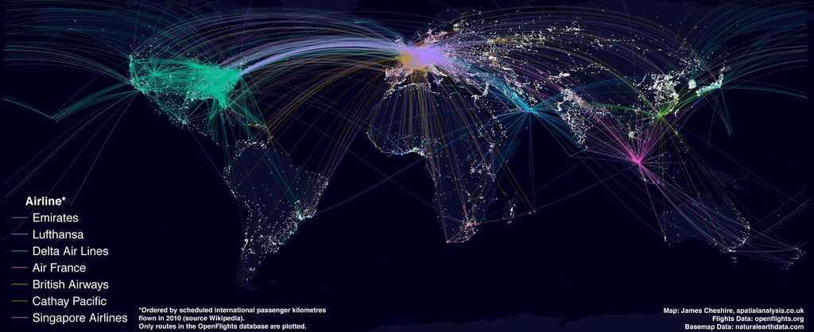

取自 http://goo.gl/q1NX26

## R語言探索之旅的課程目標

- 建立 R 的使用環境 (Ch02)
- 熟悉 R 語言基礎操作 (Ch03-04)
- 了解 R 語言的物件結構 (Ch04-08)
- 學習 R 語言的資料整理 (Ch09)
- 從無到有，完成探索性資料分析 (Ch10-13)

## Ch02：建立 R 的使用環境

## 傢俬準備好

### 環境安裝

- 主程式：[R](https://www.r-project.org/)（R-3.2.2 以上版本）
- 編輯界面：[RStudio IDE](https://www.rstudio.com/products/rstudio/)（0.99.473 以上版本）
- [疑難排解指南](https://github.com/dspim/R/wiki/R-&-RStudio-Troubleshooting-Guide)

### RStudio 界面說明

- 程式碼編輯區
- 命令列區
- 環境資訊區
- 檔案系統區

## 熟悉 RStudio 的 **命令列** 界面

### 程式的**輸入**、**輸出**、**中斷**

- 左下角的當符號 `>` 表示可以輸入指令
- 輸入 `1 + 1` 後按下 **Enter**，檢查螢幕輸出
- 輸入 `1 +` 後按下 **Enter**，檢查螢幕輸出  
  最左下角的開頭變成 `+` 表示尚未輸入完成，應繼續輸入
- 按下 **ESC**，會中斷執行中的程式 (左下角回復成 `>` 開頭)

## 熟悉 RStudio 的 **程式碼編輯** 界面

### 停留時間最多的區域

- **New File -> R Script -> Untiled1.R**
- 在程式碼編輯區中輸入 `1 + 1` 後按下 **Control + Enter**，檢查 命令列區
- 在程式碼編輯區中輸入 `1 +` 後按下 **Control + Enter**，檢查 命令列區
- 在命令列區按下 **ESC** 中斷程式

## Ch03：基礎教學 - 敘述句與數列

## 敘述句

```r
1
```

```
[1] 1
```

```r
2
```

```
[1] 2
```

```r
1; 2
```

```
[1] 1
```

```
[1] 2
```

### 筆記

- 灰底的區塊為程式碼 (輸入)，[1] 為運算結果 (輸出)
- 敘述句以**斷行 (Enter)** 或**分號 ( ; )** 作結尾
- 未完成的敘述句，命令列開頭會變成 `+`
- 可以用 **Esc** 中斷敘述句
- R 會把單引號 `'apple'` 或雙引號 `"book"` 所包覆的敘述當成字串

## 敘述句2

```r
# 基礎運算
1 + 2 + 3
```

```
[1] 6
```

```r
1 +       2 + 3
```

```
[1] 6
```

```r
x <- 10
y <- 4
(x + y) / 2 # 簡單的公式運算
```

```
[1] 7
```

### 筆記

- 基本數學運算符號 (`+`, `-`, `*`, `/`, …)
- 空白 (**space**) 不影響程式執行
- 箭號 (`<-`) 表示賦值，把箭號右邊的結果指向到R物件
- 井號 (**#**) 表示註解，使得該行不執行運算
- 在RStudio中，想要一次註解多行可用 **ctrl + shift + c**
- 在命令列中按 **ctrl + l** 可以清除當前畫面

## 最基礎的物件：數值型向量 (數列)

```r
# basic expression of integer vector
c(1, 2, 3, 4)
```

```
[1] 1 2 3 4
```

```r
# simple expression
1:4
```

```
[1] 1 2 3 4
```

```r
4:1
```

```
[1] 4 3 2 1
```

### 筆記

- 以 `c(...)` 表示 (c 取自combine之意), 元素以逗號分隔。
- 連續整數向量可以利用 `:` (冒號) 簡記，譬如數列 (1, 2, 3, 4) 在 R 語言中可利用 `1:4` 簡記
- 也可以使用 `4:1` 的簡記方式來產生 (4, 3, 2, 1) 的向量

## 如何生成有序的數值向量

```r
seq(1, 4)
```

```
[1] 1 2 3 4
```

```r
seq(1, 9, by = 2) # 間隔為2
```

```
[1] 1 3 5 7 9
```

```r
seq(1, 9, length.out = 5) # 分割長度為5
```

```
[1] 1 3 5 7 9
```

### 筆記

- 除了冒號簡記法外，可以透過`seq`函數生成有規則的數值向量(序列)
- 在`seq()` 函數中按 **tab** 鍵觀察有哪些參數可以使用
- `by` 表示數列間隔，預設為1
- `length.out` 表示數列長度

## 小挑戰

- 利用簡記法列出 1 ~ 100的數列
- 利用 `seq` 函數列出偶數數列: 2, 4, 6, 8, 10
- 觀察 `seq(1, 10, length.out=5)` 的輸出結果

## Ch03：基礎教學 - 數列的運算

## 數列的運算

R的數列運算滿足 **recycling properties**

```r
c(1, 2, 3) * c(2, 2, 2)
```

```
[1] 2 4 6
```

```r
# shorter arguments are recycled
1:3 * 2
```

```
[1] 2 4 6
```

```r
c(0.5, 1.5, 2.5, 3.5) * c(2, 1)
```

```
[1] 1.0 1.5 5.0 3.5
```

**小挑戰**

向量的四則運算，請計算以下五位女藝人的BMI

Hint: BMI = 體重 / (身高/100)^2

```r
height <- c(174, 158, 160, 168, 173)
weight <- c(52, 39, 42, 46, 48)
```

## 向量的取值

- 在`[ ]` (中括號) 中輸入元素的位置進行取值
- 使負號 (`-`) 移除給定位置元素 (反向選取)

```r
x <- c(174, 158, 160, 168, 173)
x[1]           # 選取第1個位置的元素
```

```
[1] 174
```

```r
x[c(1, 3)]     # 選取第1, 3個位置的元素
```

```
[1] 174 160
```

```r
x[c(2, 3, 1)]  # 依序取值
```

```
[1] 158 160 174
```

```r
# 在[ ]中使用負號 (-) 做反向選取
x[-1]
```

```
[1] 158 160 168 173
```

```r
x[-c(1, 3, 4)]
```

```
[1] 158 173
```

## 向量的取值2

給定條件進行取值

- 比較運算子(`>`, `<`, `>=`, `<=`, `==`, `!=`)
- 邏輯運算子 (`&`, `|`)

```r
x > 160
```

```
[1]  TRUE FALSE FALSE  TRUE  TRUE
```

```r
# 使用比較運算子 加上 `which` 函數進行取值
index <- which(x > 160)
index
```

```
[1] 1 4 5
```

```r
x[index]
```

```
[1] 174 168 173
```

```r
# 指令壓縮，將指令寫在 [ ] 中，以達到縮短程式碼的功效
x[which(x > 160)]
```

```
[1] 174 168 173
```

```r
# 配合邏輯算子進行多條件的取值
x[which(x > 160 & x < 175)]
```

```
[1] 174 168 173
```

```r
# 可以省略 which
x[x > 160 & x < 175]
```

```
[1] 174 168 173
```

## 向量的取代

- 利用 `[ ]` (中括號) 與 `<-` (箭號) 進行取代與新增元素

```r
x <- c(174, 158, 160, 168, 173)

# 取代特定位置的元素
x[2] <- 158.5 # 取代x物件的第二個元素
x
```

```
[1] 174.0 158.5 160.0 168.0 173.0
```

```r
x[c(1, 5)] <- 175
x
```

```
[1] 175.0 158.5 160.0 168.0 175.0
```

```r
# 也可以用條件篩選做取代
x[x > 160] <- 170 # 取代大於160的值為170
x
```

```
[1] 170.0 158.5 160.0 170.0 170.0
```

## 向量新增

可用 `[ ]` (中括號) 與 `<-` (箭號) 進行新增元素 - `NA` 為系統保留字，表示Not Available / Missing Values

```r
x <- c(174, 158, 160, 168, 173)
# 在 [ ] 中新增元素
x[6] <- 168
x
```

```
[1] 174 158 160 168 173 168
```

```r
x[8] <- 147
x # 未指定的元素值預設為NA
```

```
[1] 174 158 160 168 173 168  NA 147
```

```r
length(x) # 查看向量物件的長度
```

```
[1] 8
```

```r
x[length(x) + 1] <- 166 # 接續增加新元素
```

## Ch04：查詢說明檔

## 在 R 中查詢說明文件

### 各種自救措施

```r
help.start()
ab # 輸入`ab`後 按下tab
?abs   # 等同於 help(abs)
??abs
apropos("abs")
example(abs)
vignette()
vignette("Introduction", "Matrix")
```

### 筆記

- help.start: 說明檔首頁
- 自動完成 (tab鍵)：列出所有`ab`開頭的函數
- ? (一個問號)：查詢特定函數的說明檔
- ?? (兩個問號)：查詢包含特定關鍵字的說明檔
- apropos : 查詢包含特定關鍵字的函數
- example : 執行特定函數的使用範例
- vignette : 查詢R環境中各種介紹文件

## Ch05：資料型態

## R 的資料型態

- R 包含三種基本資料型態 (`class`)：
  1. 數值 (`numeric`)： `x <- c(174, 158, 160, 168, 173)`
  2. 字串 (`character`)： `y <- c("林志玲", "蔡依林", "楊丞琳", "天心", "隋棠")`
  3. 邏輯 (`logical`)： `z <- c(TRUE, FALSE, FALSE, FALSE, TRUE)`
- 利用`class`函數判斷物件型態
- `character` 內容以雙引號 (`" "`) 或單引號 (`' '`) 註記
- `logical` 內容以`TRUE` / `FALSE` 註記，亦可簡化為 `T` / `F`

```r
class(x); class(y); class(z)
```

```
[1] "numeric"
```

```
[1] "character"
```

```
[1] "logical"
```

## 資料型態的轉換

- 向量物件一次只能接受一種型態
- 在向量中給定多種型態，將會依序自動轉換：字串 > 數值 > 邏輯。

```r
# 布林值 TRUE 被轉換成1，FALSE被轉換成0
c(174, 52, TRUE)
```

```
[1] 174  52   1
```

```r
c(1.1, 2.4, TRUE, FALSE)
```

```
[1] 1.1 2.4 1.0 0.0
```

```r
c(174, 52, "林志玲") # 數值被轉換成字串
```

```
[1] "174"    "52"     "林志玲"
```

```r
# 所有元素都被轉換成字串
c("林志玲", 174, 52, TRUE)
```

```
[1] "林志玲" "174"    "52"     "TRUE"
```

## 資料型態的轉換2

- 利用以下函數自行轉換向量型態： `as.character`, `as.numeric`, `as.logical`。

```r
# 字串轉數字
a1 <- c("89", "91", "102")
as.numeric(a1)
```

```
[1]  89  91 102
```

```r
# 布林轉數字
a2 <- c(TRUE, TRUE, FALSE)
as.numeric(a2)
```

```
[1] 1 1 0
```

```r
# 數字轉布林
a3 <- c(-2, -1, 0, 1, 2) # 只有0會被轉成FALSE
as.logical(a3)
```

```
[1]  TRUE  TRUE FALSE  TRUE  TRUE
```

```r
# 數字轉字串
as.character(a3)
```

```
[1] "-2" "-1" "0"  "1"  "2"
```

## Ch06：特殊資料型態

## 特殊資料型態

- 特殊的數值型態：時間
- 處理時間的函數：`as.Date`, `strftime`, `strptime`, `as.POSIXct`, `as.POSIXlt` …

```r
Sys.time()
```

```
[1] "2016-03-15 02:04:02 CST"
```

- 特殊的字串型態：類別

```r
factor(c("male", "female", "female", "male"))
```

```
[1] male   female female male
Levels: female male
```

## `factor` 物件簡介

當一向量變數是類別型變數 (譬如：性別、教育水準) 時，  
在 `R` 語言中以 `factor` 進行定義。

```r
# variable gender with 2 "male" entries and 3 "female" entries
# rep(x, n) 函數能重複x物件n次
gender <- c(rep("male",2), rep("female", 3))
gender
```

```
[1] "male"   "male"   "female" "female" "female"
```

```r
gender <- factor(gender)
gender
```

```
[1] male   male   female female female
Levels: female male
```

```r
levels(gender)
```

```
[1] "female" "male"
```

## `factor` 物件簡介2

- 可使用 `as.numeric` 將 `factor` 物件轉換成數值
- `factor` 函數中有個多的參數可以進行設定

```r
# 1=female, 2=male internally (alphabetically)
as.numeric(gender)
```

```
[1] 2 2 1 1 1
```

```r
# change vector of labels for the levels
factor(gender, levels=c("male", "female"), labels=c("M", "F"))
```

```
[1] M M F F F
Levels: M F
```

```r
# 類別轉字串
as.character(gender)
```

```
[1] "male"   "male"   "female" "female" "female"
```

## Ch07：資料表

## 資料表 `data.frame`

- `data.frame` 是資料分析時最基本的物件
- `R` 提供將外部資料轉成 `data.frame` 的功能
- 透過`data.frame` 可以進行以下功能：
  - 資料的整理
  - 圖形的繪製
  - 模型的配適與預測

## 世界上最常見的範例資料 `iris`

```r
data("iris")
head(iris) # 列出前幾筆資料, 預設6筆
```

```
  Sepal.Length Sepal.Width Petal.Length Petal.Width Species
1          5.1         3.5          1.4         0.2  setosa
2          4.9         3.0          1.4         0.2  setosa
3          4.7         3.2          1.3         0.2  setosa
4          4.6         3.1          1.5         0.2  setosa
5          5.0         3.6          1.4         0.2  setosa
6          5.4         3.9          1.7         0.4  setosa
```

```r
dim(iris)  # 列出資料表的 rows and columns
```

```
[1] 150   5
```

## 表格的取值 - 座標

- 類似於向量取值，在中括號 `[i, j]` 中進行取值
- 逗號的前後分別表示資料表的 row and column

```r
iris[2, 3]
```

```
[1] 1.4
```

```r
iris[1:6, 1:3]
```

```
  Sepal.Length Sepal.Width Petal.Length
1          5.1         3.5          1.4
2          4.9         3.0          1.4
3          4.7         3.2          1.3
4          4.6         3.1          1.5
5          5.0         3.6          1.4
6          5.4         3.9          1.7
```

## 表格的取值 - 列

欲選取第i筆觀察資料時，使用 `[i, ]` 在column欄位留白

```r
iris[2, ]
```

```
  Sepal.Length Sepal.Width Petal.Length Petal.Width Species
2          4.9           3          1.4         0.2  setosa
```

```r
iris[c(1, 51, 101),]
```

```
    Sepal.Length Sepal.Width Petal.Length Petal.Width    Species
1            5.1         3.5          1.4         0.2     setosa
51           7.0         3.2          4.7         1.4 versicolor
101          6.3         3.3          6.0         2.5  virginica
```

## 表格的取值 - 欄

欲選取整欄資料時，有三種常用方法

```r
iris[,1] # 欄位名稱未知
iris$Sepal.Length # 已知欄位名稱
iris[["Sepal.Length"]] # 已知欄位名稱
```

```
  [1] 5.1 4.9 4.7 4.6 5.0 5.4 4.6 5.0 4.4 4.9 5.4 4.8 4.8 4.3 5.8 5.7 5.4
 [18] 5.1 5.7 5.1 5.4 5.1 4.6 5.1 4.8 5.0 5.0 5.2 5.2 4.7 4.8 5.4 5.2 5.5
 [35] 4.9 5.0 5.5 4.9 4.4 5.1 5.0 4.5 4.4 5.0 5.1 4.8 5.1 4.6 5.3 5.0 7.0
 [52] 6.4 6.9 5.5 6.5 5.7 6.3 4.9 6.6 5.2 5.0 5.9 6.0 6.1 5.6 6.7 5.6 5.8
 [69] 6.2 5.6 5.9 6.1 6.3 6.1 6.4 6.6 6.8 6.7 6.0 5.7 5.5 5.5 5.8 6.0 5.4
 [86] 6.0 6.7 6.3 5.6 5.5 5.5 6.1 5.8 5.0 5.6 5.7 5.7 6.2 5.1 5.7 6.3 5.8
[103] 7.1 6.3 6.5 7.6 4.9 7.3 6.7 7.2 6.5 6.4 6.8 5.7 5.8 6.4 6.5 7.7 7.7
[120] 6.0 6.9 5.6 7.7 6.3 6.7 7.2 6.2 6.1 6.4 7.2 7.4 7.9 6.4 6.3 6.1 7.7
[137] 6.3 6.4 6.0 6.9 6.7 6.9 5.8 6.8 6.7 6.7 6.3 6.5 6.2 5.9
```

## 表格的取值 - 篩選

利用條件式做篩選

```r
iris[iris$Sepal.Length > 5.5 & iris$Species=="setosa", ]
```

```
   Sepal.Length Sepal.Width Petal.Length Petal.Width Species
15          5.8         4.0          1.2         0.2  setosa
16          5.7         4.4          1.5         0.4  setosa
19          5.7         3.8          1.7         0.3  setosa
```

## 課程回顧

- 建立 R 的使用環境 (Ch01-02)
  - RStudio介面、tab鍵
- 熟悉 R 語言基礎操作 (Ch03-04)
  - 向量的運算、`[]`取值、`?`查詢說明
- 了解 R 語言的物件的結構 (Ch05-07)
  - 數值、字串、邏輯型態
  - `data.frame`資料表

## 繼續學習之路

- 了解自己的需求，詢問關鍵字與函數
- [Taiwan R User Group](http://www.meetup.com/Taiwan-R)，mailing list: Taiwan-useR-Group-list@meetup.com
- [ptt R_Language版](https://www.ptt.cc/bbs/R_Language/index.html)
- [R軟體使用者論壇](https://groups.google.com/forum/#!forum/taiwanruser)
- [StackOverflow](http://stackoverflow.com/)
- 歡迎來信 johnson@dsp.im 或其他DSP優秀教師多多交流